# Project:1

# OLYMPICS DATA ANALYSIS(1976-2008)

## Domain: Data Analyst

[figure not shown]

```python
from IPython.display import Image
Image(filename="summer olympics logo.png", width=400)
```

# Olympics Data Analysis Project

**Tools:** Python (pandas, matplotlib, seaborn), Jypyter Notebook, Excel(for pivot checks)

# Project Objective

The main objective of this project is to perform a comprehensive analysis of the Summer Olympics dataset(1976-2008) to understand global performance trends in varoius sports disciplines. The project aims to identify the Top performing countries, Most successful athletes, and sports with the highest number of medals. It also explores how medal distribution has changed over time and highlights the participating and performance differences between male and female athletes.

Using Python-based data analytics tools such as pandas, matplotlib, and seaborn, the dataset is cleaned, explored, and visualized to uncover hidden insights.

The ultimate goal of this project is to demonstrate how data analytics and visualization techniques can be applied to large scale sports datasets to extract meaningful insights that help understand performance patterns and histrical achievements in the Olympics.

# Dataset Description

**File Name:** Summer-Olympic-medals-1976-to-2008.csv

**Total Rows:** 15,433

**Total Colunms:** 11

**Key Colunms:** City, Year, Sport, Discipline, Event, Athlete, Gender, Country code, Country, Event_gender, Medal.

**Data Range:** 1976 - 2008

**Description:** The dataset contains information aboyt all athletes who won medals in the Summer Olympic Games between 1976 and 2008. Eash row representd one medal awarded to an athlete ( for team events,each team member is listed separately). It includes details such as the year, host city, sport, athlete name, country, gemder, event, and type of medal(Gold, Silver, or Bronze)

## Key Visuals

### 1. Top 10 Countries by Medal Count

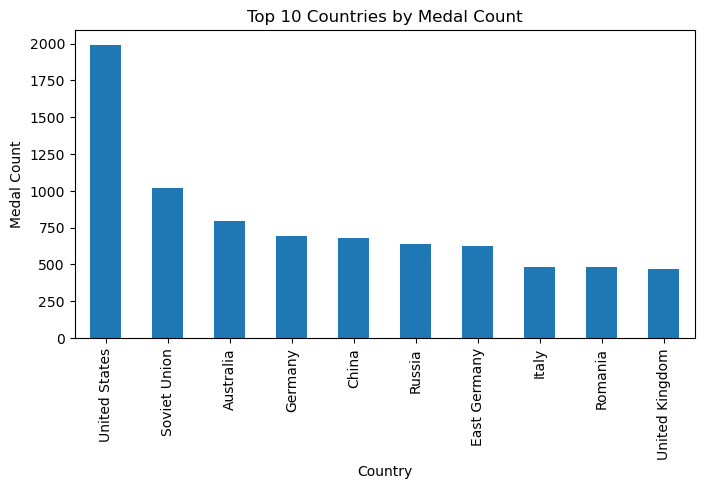

```python
from IPython.display import Image
Image(filename="top_countries.png",width=600)
```

*Figure 1: Top 10 Countries by Medal Count.*

### 2. Top 10 Athletes with Most Medals

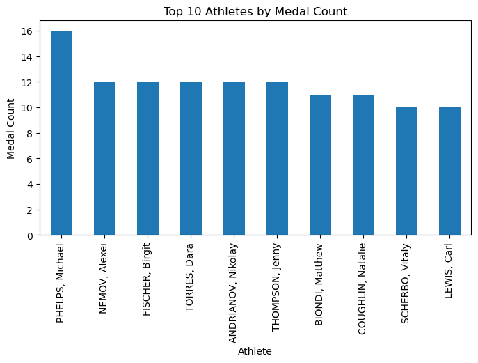

```python
from IPython.display import Image
Image(filename="top_athletes.png",width=600)
```

*Figure 2: Top 10 Athletes by Medal Count.*

### 3. Gender Distribution of Medals

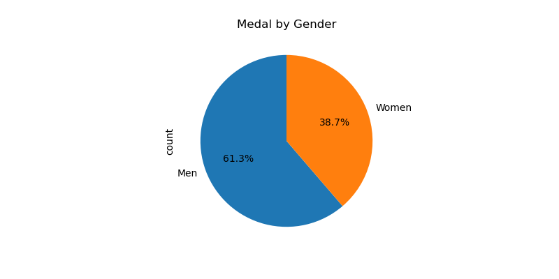

```python
from IPython.display import Image
Image(filename="gender_count.png",width=450)
```

*Figure 3: Medal by Gender.*

### 4. Top Sports by Medal Count

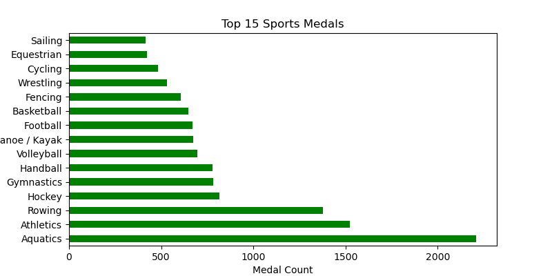

```python
from IPython.display import Image
Image(filename="top_sports.png",width=600)
```

*Figure 4: Top 15 Sports Medals.*

### 5. Country Trend Example – USA

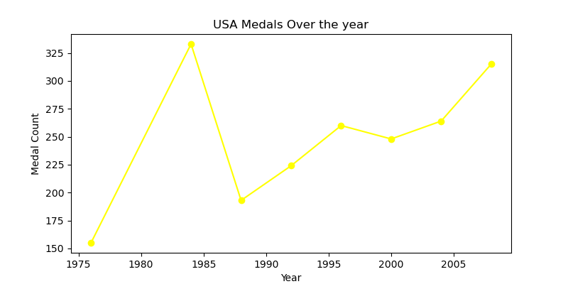

```python
from IPython.display import Image
Image(filename="usa_trend.png",width=600)
```

*Figure 5:Visualize the trend for a top single country.*

### 6. Total Medals by Year

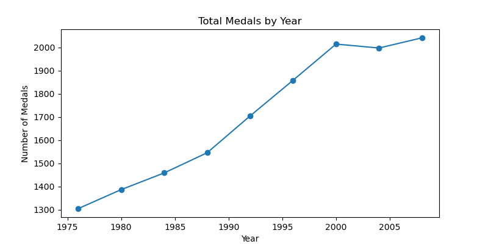

```python
from IPython.display import Image
Image(filename="medals_by_year.png",width=600)
```

*Figure 6: Medals by Year.*

## 7.Total Medals by Each Country per Year

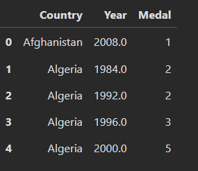

```python
from IPython.display import Image
Image(filename="top_country_per_year.png")
```

*Figure 6: Shows how many medals each country won in each Olympic year.*

### 8.Top Country per Year

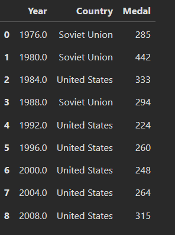

```python
from IPython.display import Image
Image(filename="country_year.png")
```

*Figure 7: Displays which country achieved the highest medal count in each Olympic year.*

## Conclusion & Future Work

### Conclusion

The analysis of the Summer Olympics dataset (1976 – 2008) reveals several interesting patterns and performance trends.  
The **United States** maintained consistent dominance across most Olympic years, while the **Soviet Union** held strong positions before the 1990s.  
Countries such as **China**, **Australia**, and **Germany** also showed significant growth in their medal tallies during the later years.

*This concludes the Olympics Data Analysis project demonstrating how data analytics and visualization can reveal meaningful insights from large-scale sports data.*

```python
import pandas as pd
import numpy as np
import matplotlib.pyplot as plt
import seaborn as sns
```

```python
df = pd.read_csv(r"C:\Users\sathv\Downloads\Summer-Olympic-medals-1976-to-2008.csv", encoding='latin1')
df.head()
```

|  | City | Year | Sport | Discipline | Event | Athlete | Gender | Country_Code | Country | Event_gender | Medal |
| --- | --- | --- | --- | --- | --- | --- | --- | --- | --- | --- | --- |
| 0 | Montreal | 1976.0 | Aquatics | Diving | 3m springboard | KÖHLER, Christa | Women | GDR | East Germany | W | Silver |
| 1 | Montreal | 1976.0 | Aquatics | Diving | 3m springboard | KOSENKOV, Aleksandr | Men | URS | Soviet Union | M | Bronze |
| 2 | Montreal | 1976.0 | Aquatics | Diving | 3m springboard | BOGGS, Philip George | Men | USA | United States | M | Gold |
| 3 | Montreal | 1976.0 | Aquatics | Diving | 3m springboard | CAGNOTTO, Giorgio Franco | Men | ITA | Italy | M | Silver |
| 4 | Montreal | 1976.0 | Aquatics | Diving | 10m platform | WILSON, Deborah Keplar | Women | USA | United States | W | Bronze |

```python
df.info()
df.describe()
```

```
<class 'pandas.core.frame.DataFrame'>
RangeIndex: 15433 entries, 0 to 15432
Data columns (total 11 columns):
 #   Column        Non-Null Count  Dtype
---  ------        --------------  -----
 0   City          15316 non-null  object
 1   Year          15316 non-null  float64
 2   Sport         15316 non-null  object
 3   Discipline    15316 non-null  object
 4   Event         15316 non-null  object
 5   Athlete       15316 non-null  object
 6   Gender        15316 non-null  object
 7   Country_Code  15316 non-null  object
 8   Country       15316 non-null  object
 9   Event_gender  15316 non-null  object
 10  Medal         15316 non-null  object
dtypes: float64(1), object(10)
memory usage: 1.3+ MB
```

|  | Year |
| --- | --- |
| count | 15316.000000 |
| mean | 1993.620789 |
| std | 10.159851 |
| min | 1976.000000 |
| 25% | 1984.000000 |
| 50% | 1996.000000 |
| 75% | 2004.000000 |
| max | 2008.000000 |

```python
df.isnull().sum()
```

```
City            117
Year            117
Sport           117
Discipline      117
Event           117
Athlete         117
Gender          117
Country_Code    117
Country         117
Event_gender    117
Medal           117
dtype: int64
```

```python
df= df.drop(columns=['Country_code', 'Event_gender'],errors='ignore')
```

```python
df= df.apply(lambda x: x.str.strip() if x.dtype== "object" else x)
```

```python
df= df.drop_duplicates()
```

```python
df.head()
df.info()
```

```
<class 'pandas.core.frame.DataFrame'>
Index: 15316 entries, 0 to 15432
Data columns (total 10 columns):
 #   Column        Non-Null Count  Dtype
---  ------        --------------  -----
 0   City          15315 non-null  object
 1   Year          15315 non-null  float64
 2   Sport         15315 non-null  object
 3   Discipline    15315 non-null  object
 4   Event         15315 non-null  object
 5   Athlete       15315 non-null  object
 6   Gender        15315 non-null  object
 7   Country_Code  15315 non-null  object
 8   Country       15315 non-null  object
 9   Medal         15315 non-null  object
dtypes: float64(1), object(9)
memory usage: 1.3+ MB
```

```
Country
United States     1992
Soviet Union      1021
Australia          798
Germany            691
China              679
Russia             638
East Germany       626
Italy              486
Romania            482
United Kingdom     467
Name: count, dtype: int64
```

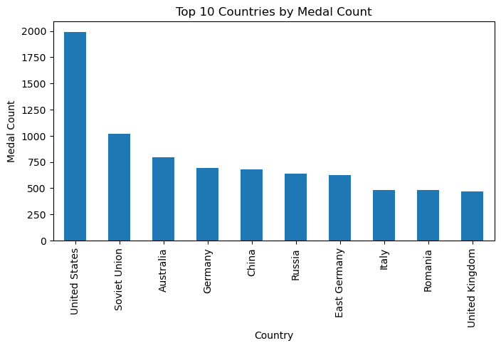

```python
#Top 10 countries by Medals
top_countries= df['Country'].value_counts().head(10)
print(top_countries)

top_countries.plot(kind="bar", figsize=(8,4), title="Top 10 Countries by Medal Count")
plt.ylabel("Medal Count")
plt.show()
plt.savefig('top_countries.png', bbox_inches='tight')
plt.close()
```

```
Athlete
PHELPS, Michael       16
NEMOV, Alexei         12
FISCHER, Birgit       12
TORRES, Dara          12
ANDRIANOV, Nikolay    12
THOMPSON, Jenny       12
BIONDI, Matthew       11
COUGHLIN, Natalie     11
SCHERBO, Vitaly       10
LEWIS, Carl           10
Name: count, dtype: int64
```

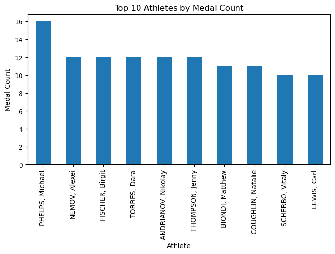

```python
#Top 10 Athletes with Most Medals

top_athletes = df["Athlete"].value_counts().head(10)
print(top_athletes)

top_athletes.plot.bar(figsize=(8,4), title= "Top 10 Athletes by Medal Count")
plt.xlabel("Athlete")
plt.ylabel("Medal Count")
plt.savefig("top_athletes.png", bbox_inches="tight")
plt.show()
```

```
Gender
Men      9388
Women    5928
Name: count, dtype: int64
```

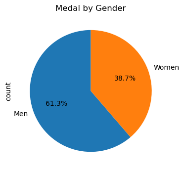

```python
#Gender Distribution in Event

gender_count= df["Gender"].value_counts()
print(gender_count)
gender_count.plot(kind="pie",color=["pink","lightblue"],autopct="%1.1f%%",startangle=90, figsize=(8,4))
plt.title("Medal by Gender")
plt.savefig("gender_count.png")
plt.show()
```

```
Sport
Aquatics         2210
Athletics        1523
Rowing           1377
Hockey            817
Gymnastics        783
Handball          780
Volleyball        695
Canoe / Kayak     672
Football          669
Basketball        646
Fencing           606
Wrestling         533
Cycling           483
Equestrian        423
Sailing           417
Name: count, dtype: int64
```

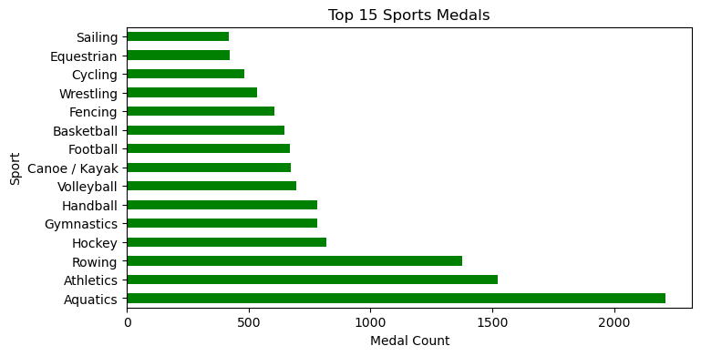

```python
#Medals by Sport

top_sports= df["Sport"].value_counts().head(15)
print(top_sports)

top_sports.plot.barh(color="green", figsize=(8,4))
plt.title("Top 15 Sports Medals")
plt.xlabel("Medal Count")
plt.savefig("top_sports.png")
plt.show()
```

```python
#Total Medals by each country per year
country_year= df.groupby(["Country","Year"])["Medal"].count().reset_index()
country_year.head()
```

|  | Country | Year | Medal |
| --- | --- | --- | --- |
| 0 | Afghanistan | 2008.0 | 1 |
| 1 | Algeria | 1984.0 | 2 |
| 2 | Algeria | 1992.0 | 2 |
| 3 | Algeria | 1996.0 | 3 |
| 4 | Algeria | 2000.0 | 5 |

```python
#Creating a pivot table
pivot_table= pd.pivot_table(df,
                            index="Country",
                            columns="Year",
                            values="Medal",
                            aggfunc="count",
                            fill_value=0)
pivot_table.head()
```

| Year Country | 1976.0 | 1980.0 | 1984.0 | 1988.0 | 1992.0 | 1996.0 | 2000.0 | 2004.0 | 2008.0 |
| --- | --- | --- | --- | --- | --- | --- | --- | --- | --- |
| Afghanistan | 0 | 0 | 0 | 0 | 0 | 0 | 0 | 0 | 1 |
| Algeria | 0 | 0 | 2 | 0 | 2 | 3 | 5 | 0 | 2 |
| Argentina | 0 | 0 | 0 | 13 | 2 | 20 | 20 | 47 | 51 |
| Armenia | 0 | 0 | 0 | 0 | 0 | 2 | 1 | 0 | 6 |
| Australia | 24 | 12 | 50 | 34 | 57 | 132 | 183 | 157 | 149 |

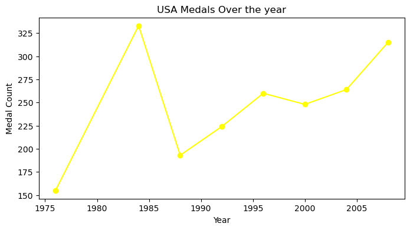

```python
#Visualize the trend for a top single country
usa_trend= country_year[country_year["Country"]=="United States"]

plt.figure(figsize=(8,4))
plt.plot(usa_trend["Year"], usa_trend["Medal"], marker="o", color="yellow")
plt.title("USA Medals Over the year")
plt.xlabel("Year")
plt.ylabel("Medal Count")
plt.savefig("usa_trend.png")
plt.show()
```

```python
#Top Countries per Year
top_country_per_year=(
    country_year.sort_values(["Year","Medal"],ascending=[True,False])
    .groupby("Year").first().reset_index()
)
top_country_per_year.head(10)
```

|  | Year | Country | Medal |
| --- | --- | --- | --- |
| 0 | 1976.0 | Soviet Union | 285 |
| 1 | 1980.0 | Soviet Union | 442 |
| 2 | 1984.0 | United States | 333 |
| 3 | 1988.0 | Soviet Union | 294 |
| 4 | 1992.0 | United States | 224 |
| 5 | 1996.0 | United States | 260 |
| 6 | 2000.0 | United States | 248 |
| 7 | 2004.0 | United States | 264 |
| 8 | 2008.0 | United States | 315 |

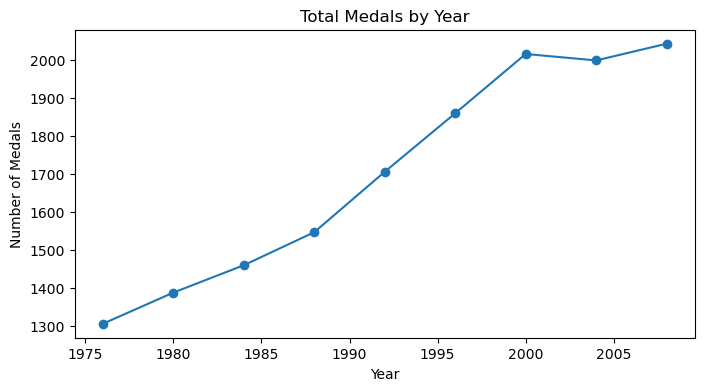

```python
#Medals by Year

medals_by_year = df['Year'].value_counts().sort_index()
plt.figure(figsize=(8,4))
plt.plot(medals_by_year.index, medals_by_year.values, marker='o')
plt.title('Total Medals by Year')
plt.xlabel('Year')
plt.ylabel('Number of Medals')
plt.savefig("medals_by_year.png")
plt.show()
```